# Project 4

Chris Tyndall

October 1, 2016

# Exploratory Data Analysis of Wine Quality

The Wine Quality data sets contain information on various chemical properties of both red and white wines from the Vinho Verde region in Portugal and an expert quality rating for the particular wine, based on a scale from 1-10. I will first explore the Red Wine Quality dataset to determine if any chemical properties show any trends with the quality of wine. Then, I will also explore the White Wine Quality data and compare if the properties are similar for both red and white wine and if they show similar trends to the quality of the wine.

### Basic Data Information

```
##  [1] "fixed.acidity"        "volatile.acidity"     "citric.acid"
##  [4] "residual.sugar"       "chlorides"            "free.sulfur.dioxide"
##  [7] "total.sulfur.dioxide" "density"              "pH"
## [10] "sulphates"            "alcohol"              "quality"
## [13] "type"
```

```
## 'data.frame':    1599 obs. of  13 variables:
##  $ fixed.acidity       : num  7.4 7.8 7.8 11.2 7.4 7.4 7.9 7.3 7.8 7.5 ...
##  $ volatile.acidity    : num  0.7 0.88 0.76 0.28 0.7 0.66 0.6 0.65 0.58 0.5 ...
##  $ citric.acid         : num  0 0 0.04 0.56 0 0 0.06 0 0.02 0.36 ...
##  $ residual.sugar      : num  1.9 2.6 2.3 1.9 1.9 1.8 1.6 1.2 2 6.1 ...
##  $ chlorides           : num  0.076 0.098 0.092 0.075 0.076 0.075 0.069 0.065 0.073 0.071 ...
##  $ free.sulfur.dioxide : num  11 25 15 17 11 13 15 15 9 17 ...
##  $ total.sulfur.dioxide: num  34 67 54 60 34 40 59 21 18 102 ...
##  $ density             : num  0.998 0.997 0.997 0.998 0.998 ...
##  $ pH                  : num  3.51 3.2 3.26 3.16 3.51 3.51 3.3 3.39 3.36 3.35 ...
##  $ sulphates           : num  0.56 0.68 0.65 0.58 0.56 0.56 0.46 0.47 0.57 0.8 ...
##  $ alcohol             : num  9.4 9.8 9.8 9.8 9.4 9.4 9.4 10 9.5 10.5 ...
##  $ quality             : int  5 5 5 6 5 5 5 7 7 5 ...
##  $ type                : chr  "red" "red" "red" "red" ...
```

```
## 'data.frame':    4898 obs. of  13 variables:
##  $ fixed.acidity       : num  7 6.3 8.1 7.2 7.2 8.1 6.2 7 6.3 8.1 ...
##  $ volatile.acidity    : num  0.27 0.3 0.28 0.23 0.23 0.28 0.32 0.27 0.3 0.22 ...
##  $ citric.acid         : num  0.36 0.34 0.4 0.32 0.32 0.4 0.16 0.36 0.34 0.43 ...
##  $ residual.sugar      : num  20.7 1.6 6.9 8.5 8.5 6.9 7 20.7 1.6 1.5 ...
##  $ chlorides           : num  0.045 0.049 0.05 0.058 0.058 0.05 0.045 0.045 0.049 0.044 ...
##  $ free.sulfur.dioxide : num  45 14 30 47 47 30 30 45 14 28 ...
##  $ total.sulfur.dioxide: num  170 132 97 186 186 97 136 170 132 129 ...
##  $ density             : num  1.001 0.994 0.995 0.996 0.996 ...
##  $ pH                  : num  3 3.3 3.26 3.19 3.19 3.26 3.18 3 3.3 3.22 ...
##  $ sulphates           : num  0.45 0.49 0.44 0.4 0.4 0.44 0.47 0.45 0.49 0.45 ...
##  $ alcohol             : num  8.8 9.5 10.1 9.9 9.9 10.1 9.6 8.8 9.5 11 ...
##  $ quality             : int  6 6 6 6 6 6 6 6 6 6 ...
##  $ type                : chr  "white" "white" "white" "white" ...
```

The dataset contained 12 variables and I added another for type to distguish red wines and white wines for later analysis. 11 of the original 12 variables are chemical properties of the wine and 1 is a wine quality rating as given by wine experts. All data are numeric. There was also a blank index column that I’ve removed from the dataset.

The red wines have 1599 observations and the white wines much more with 4898, both with the same variables.

### Variables distributions (Univariate Analysis)

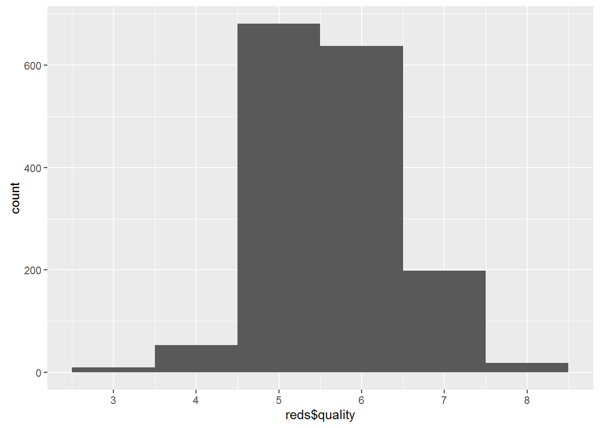

Becauase I want to find relations to the quality of wines, I first want to check the Quality variable to see if the rating seem reasonable. I created a histogram above to verify that the data appears reasonable. Values are all integers ranging from 3-8. This seems reasonable since the ratings are meant to be on a scale of 1-10. Therefore, none of the wines were terrible and none were perfect. Though there are only 6 different ratings given, the frequencies show a normal distribution of ratings based off the histogram with a slight positive skew. This distribution makes sense for the ratings as an average quality wine is likely more common than a particularly good or particular bad wine. However, this means there are less data points for the extremes of the dataset. It would be more useful to have a flat distribution so that all quality ratings are well represented in the data set.

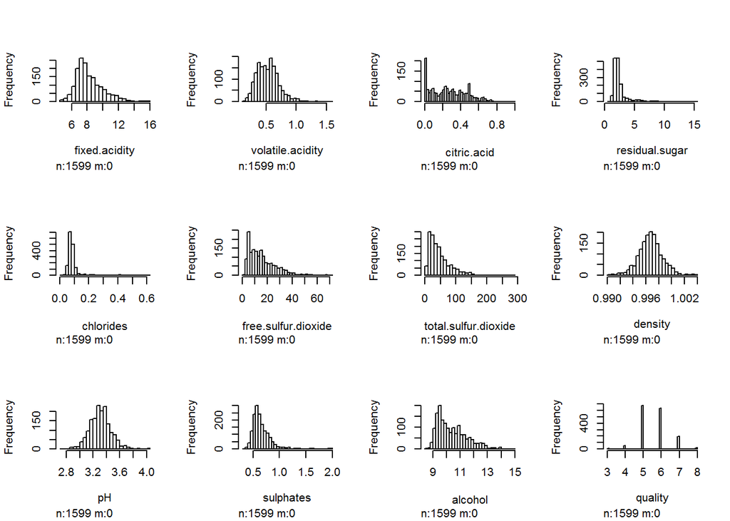

I’ve explored the rest of the variables distributions to see if there are any particularly strange variables above. Plotting histograms for each variable, we see that most have a relatively normal shape. Density looks the most normal and citric.acid the least as it is more uniform. Several variables show positively skewed results including free.sulfur.dioxide, total.sulfar.dioxide, residual.sugar, and alcohol.

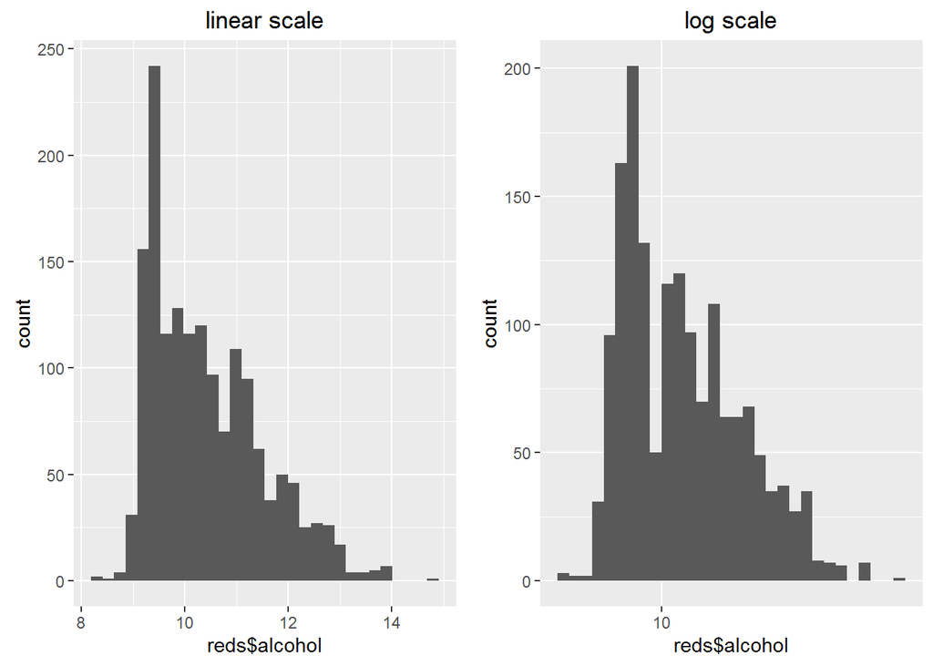

The alcohol histogram looks to potentially show bimodal distribution so I will investigate it closer. Looking at the histogram for alcohol more closely, its possible there is a bimodal distribution with peaks around 9.5% and 11%. A log scale transformation appears to highlight this possible distribution.

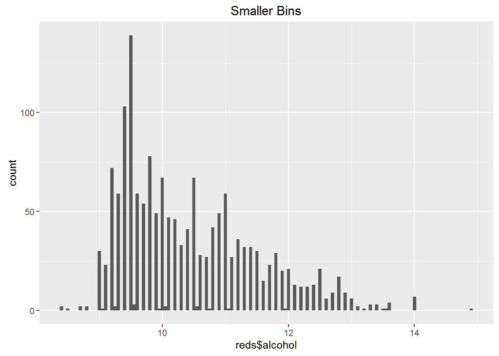

But. it may be that there just few values for alcohol around 10%. I made smaller bins in the plot above, and this more detailed histogram does not show a bimodal distribution, but rather looks like a long-tailed and noisy set of data.

I did observe that that most wines are reported to the nearest 0.1% since a binwidth of 0.05% shows discrete steps.

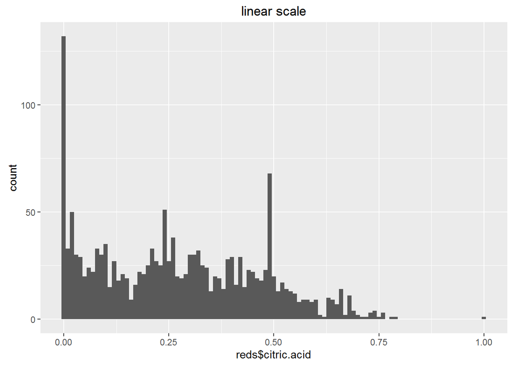

Citric Acid looks like it has a rather flat distribution. A closer look at Citric Acid shows an abnormally large peak at density of 0.0 g/dm^3 plus a potential outlier at 1 g/dm^3. Perhaps the 0’s are missing data? The data info does say that there are no missing values, so perhaps there is a group of wines that truly have no citric acid. The smallest measurement is 0.01 g/dm^3 so likely many wines have such trace amounts of citric acid that the measurement data could not resolve the value.

```
## [1] 132
```

There are 132 out of 1599 values of 0 g/dm^3.

### Correlations (Bivariate Analysis)

The Red Wines dataset includes 1599 observations which is still small enough that I can run a correlation table and generate plots and calculate correlations for all pairs within the table. I am most interested in the correlations to quality rating, but also any potential strong correlations between variables. After running a correlation table, the 4 variables that show the strongest correlation to quality in descending order are Alcohol, Volatile Acidity, Sulphates, and Citric Acid.

#### Correlations to Quality

The property with the strongest linear correlation to quality is alcohol. The data for Quality Ratings is very discrete and there is quite a large spread across the alcohol variable. Volatile.acidity has a negative correlation, and sulphates and citric.acid all have at least some weak correlation (|R| > 0.2). A series of boxplots grouped by quality rating shows the trends a little more distinctly. (Note - Quality is along the x-axis for box-plots)

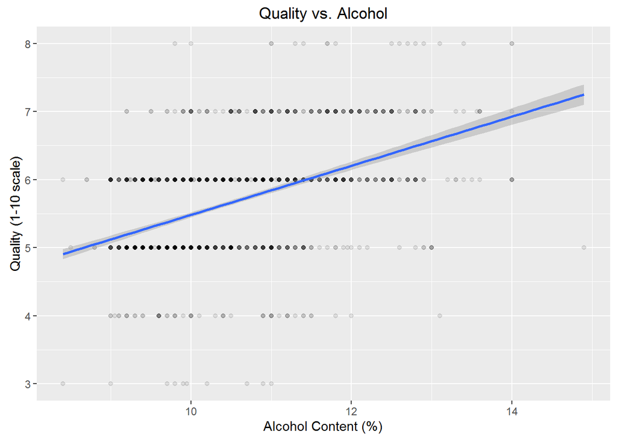

I want to compare alcohol to quality, but the scatterplot above is difficult to read because there are so few quality ratings and there is a large spread in alcohol values for each quality rating. I will try plotting it a different way.

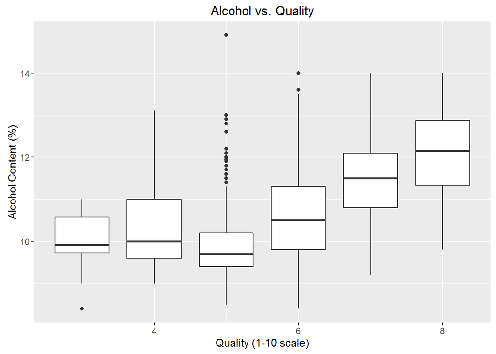

I’ve replotted alcohol versus quality using a boxplot, and placed quality on the x-axis. The generally positive trend is now much easier to see. In the following plots, I repeat the boxplot visualization for the other top correlated variables. I also see that there are several outliers for quality rating = 5.

I created similar boxplots for the remaining 3 variables with higher correlation values below:

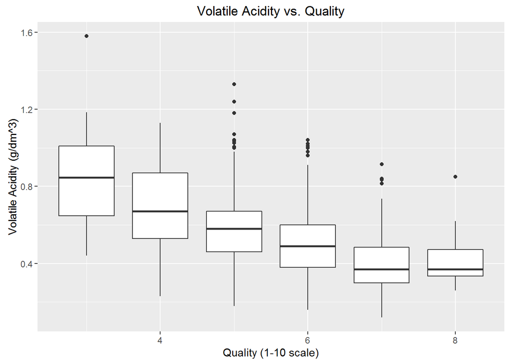

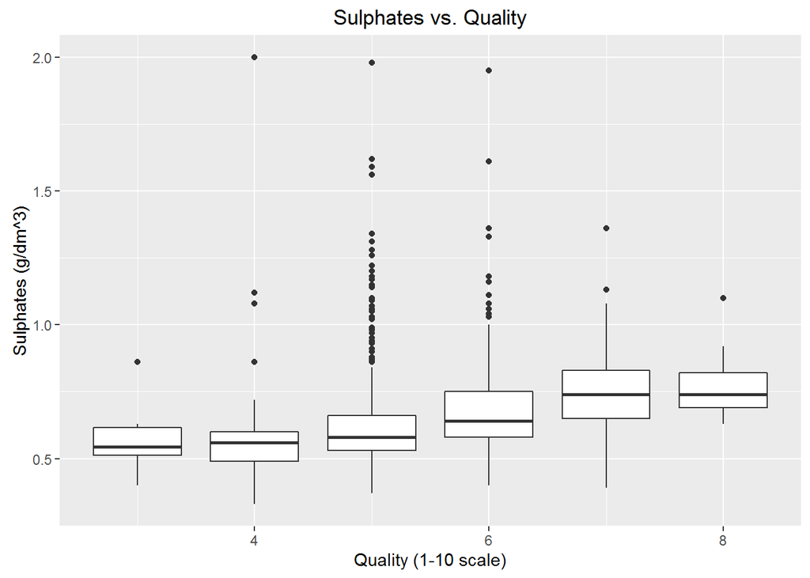

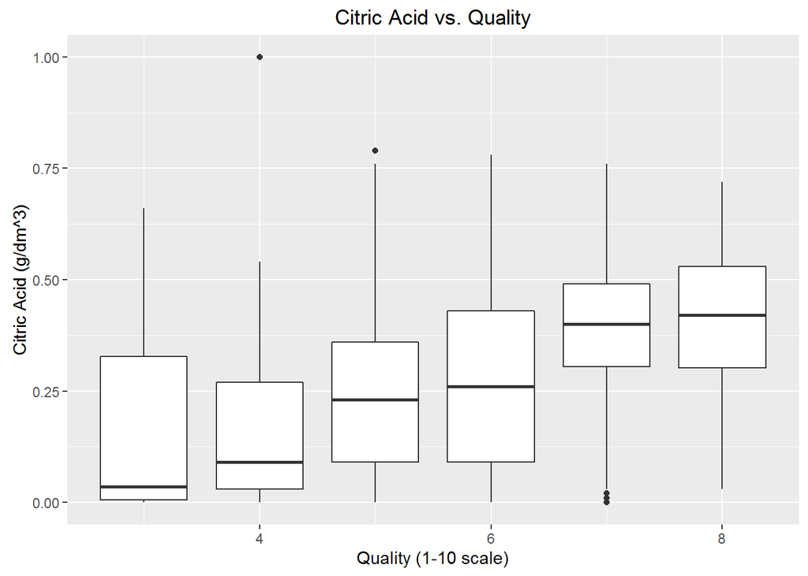

Volatile Acidity and Citric Acid each have a few outliers (including the Citric Acid outlier mentioned earlier) while Sulphates have many. Each boxplot does show an underlying positive or negative correlation to the median value for each quality level despite the spread in values. Volatile Acidity is the only that shows a negative trend, which could be explained by the wineQuality notes provided with this dataset state that wines with high volatile acidity often have an unpleasant vingary taste. To summarize the correlations to quality in decreasing strength:

Alcohol : Positive (R = 0.476)

Volatile Acidity : Negative (R = -0.391)

Sulphates : Positive, weak (R = 0.251)

Citric Acid : Positive, weak (R = 0.226)

The low R-values indicate that the trend does not necessarily hold true for most wines, so it seems that a wine of particular quality can have a large range in chemical properties.

#### Correlations between variables

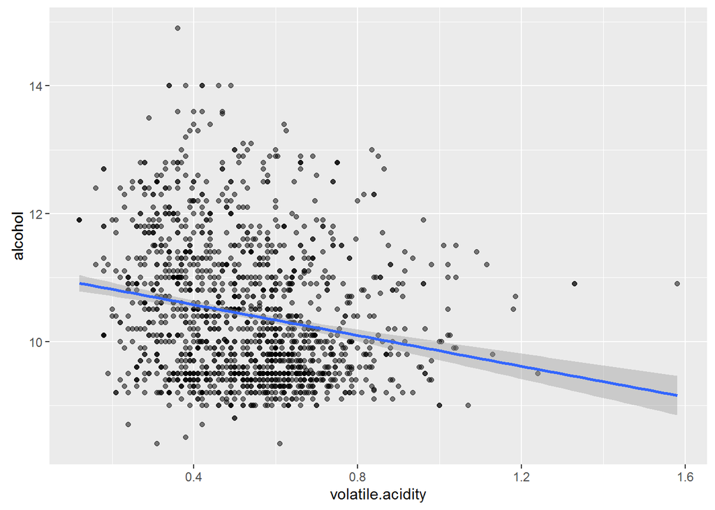

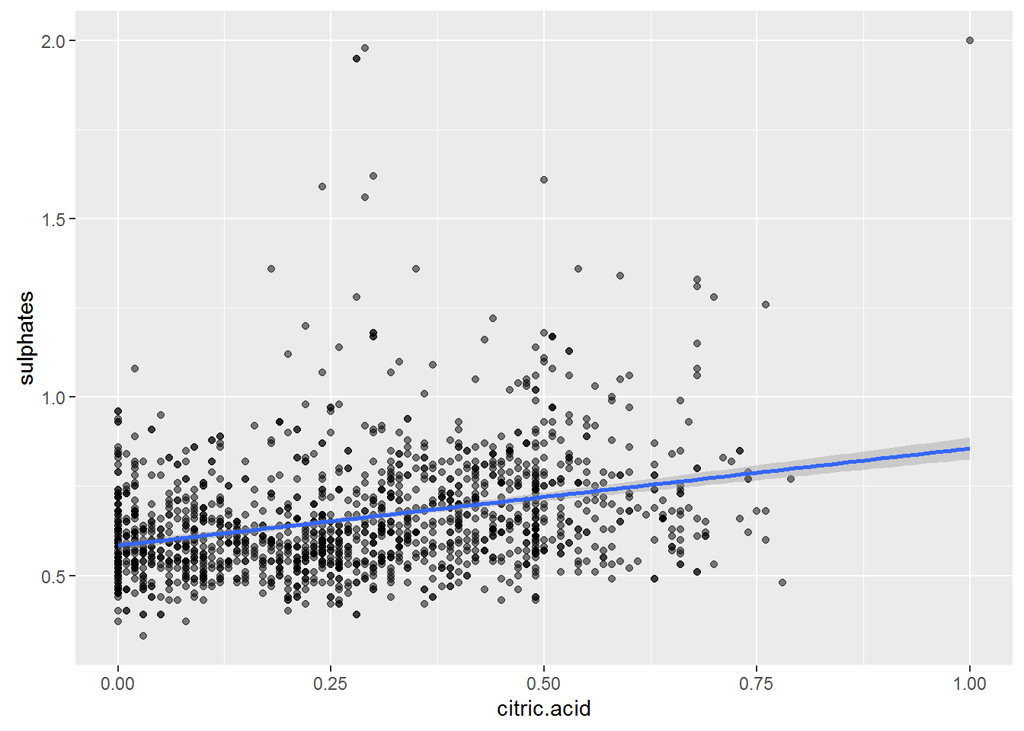

I’ve plotted a scatter plot with a linear model trendline for citric acid vs sulphates and for volatile.acidity vs. alcohol. They are interesting to me because of the top 4 correlated variables, the strongest correlation between them is voltalite.acidity to citric.acid (R = -.552). The correlation between citric.acid to sulphates (R = .313) is greater that the correlation between each of them and quality (R = .226 and .251 respectively). Whether or not the correlations between them are related to the correlations to quality remains uncertain.

Looking at the rest of the variables, there are some stronger correlations among certain pairs (R value in parentheses). These include:

fixed.acidity - citric.acid (0.672)

fixed.acidity - density (0.668)

free.sulfur.dioxide - total.sulfur.dioxide (0.668)

fixed.acidity - pH (-0.683)

volatile.acidity - citric.acid (-.552)

citric.acid - pH (-0.542)

density - alcohol (0.498)

I will not be exploring some of these variables though, because I am mostly focusing on alcohol, volatile acidity, sulphates, and citric acid.

### Linear model for quality (Multivariate analysis)

None of the variables have higher than an R<sup>2</sup> value greater than 0.227, thus any correlations are rather weak. This is mostly due to the large spread chemical property values for each of the quality ratings. The medians show decent trends, so perhaps a larger dataset would show stronger correlations.

When creating a linear model there are noticeable increases in R<sup>2</sup> when adding alcohol, then volatile.acidity, then sulphates to the model. The addition of citric.acid does not improve the model which still has only a 0.336 R<sup>2</sup> value. This could possibly be partially explained by correlation of citric.acid to other variables, particularly sulphates, or due to the overall weak nature of the correlation.

```
##
## Calls:
## m1: lm(formula = quality ~ alcohol, data = reds)
## m2: lm(formula = quality ~ alcohol + volatile.acidity, data = reds)
## m3: lm(formula = quality ~ alcohol + volatile.acidity + sulphates,
##     data = reds)
## m4: lm(formula = quality ~ alcohol + volatile.acidity + sulphates +
##     citric.acid, data = reds)
##
## ================================================================
##                        m1         m2         m3         m4
## ----------------------------------------------------------------
##   (Intercept)        1.875***   3.095***   2.611***   2.646***
##                     (0.175)    (0.184)    (0.196)    (0.201)
##   alcohol            0.361***   0.314***   0.309***   0.309***
##                     (0.017)    (0.016)    (0.016)    (0.016)
##   volatile.acidity             -1.384***  -1.221***  -1.265***
##                                (0.095)    (0.097)    (0.113)
##   sulphates                                0.679***   0.696***
##                                           (0.101)    (0.103)
##   citric.acid                                        -0.079
##                                                      (0.104)
## ----------------------------------------------------------------
##   R-squared             0.227      0.317      0.336      0.336
##   adj. R-squared        0.226      0.316      0.335      0.334
##   sigma                 0.710      0.668      0.659      0.659
##   F                   468.267    370.379    268.912    201.777
##   p                     0.000      0.000      0.000      0.000
##   Log-likelihood    -1721.057  -1621.814  -1599.384  -1599.093
##   Deviance            805.870    711.796    692.105    691.852
##   AIC                3448.114   3251.628   3208.768   3210.186
##   BIC                3464.245   3273.136   3235.654   3242.448
##   N                  1599       1599       1599       1599
## ================================================================
```

How does this model do in predicting the quality of wine given these 4 chemical properties?

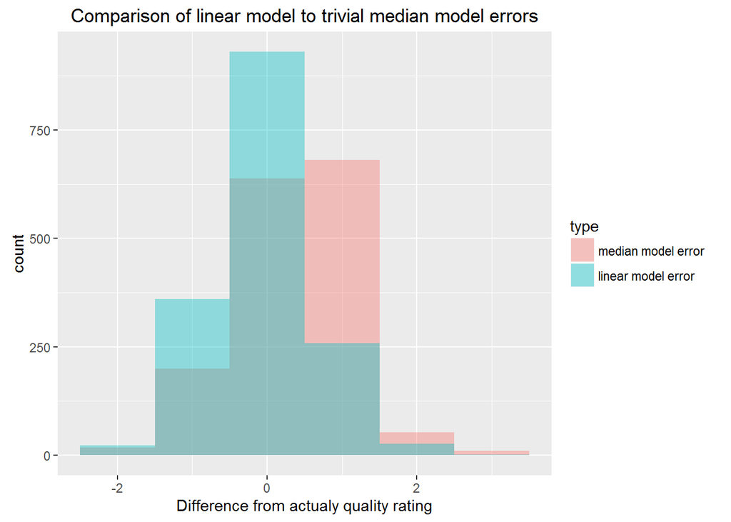

```
## [1] 0.7152859
```

```
## [1] 0.8075694
```

I applied the linear model to each red wine observations and rounded the result to the nearest integer quality rating. I then subracted this predicted value from the actual value and generated a histogram of the errors in the plot above. For comparison, I assigned a prediction that simply uses the median value (Quality = 6) of the data set and compared the results.

The linear model does accurately predict more wines correctly (where the difference is 0) than simply using the median. Overall, the standard deviation of the errors are slightly less for the linear model than the trivial median model (0.715 vs 0.808), so the linear model does in fact have some predictive power though it is relatively limited.

If I am to pick out a red wine from the Vinho Verde given chemical properties, I would choose one with higher alcohol content, low volatile acidity, and higher sulphates rather than choosing one at random. Unfortunately, likley only the alcohol content would be given on the label.

### Comparison to White wines

#### Variable distributions comparison

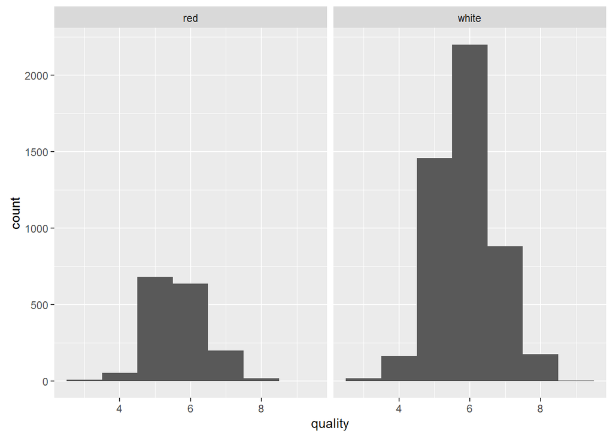

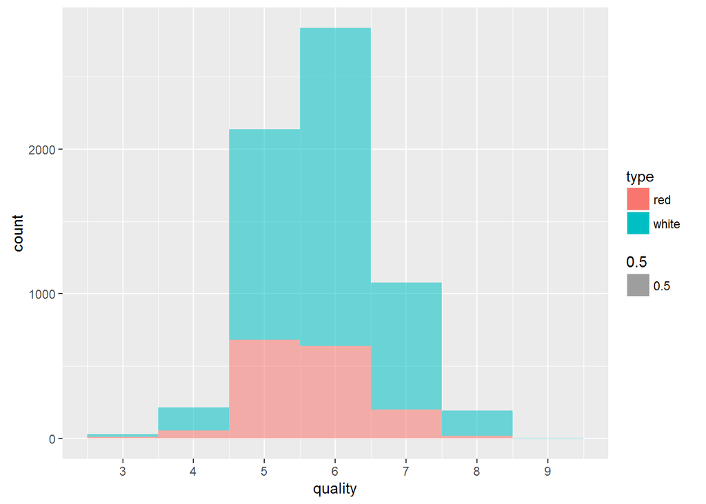

Now that I’ve explored the red dataset and focused on just a few variables, I want to compare to the white wines. First I check the quality distribution of the white wines and compare them to the reds. There are many more observations of white wines. The distribution is also normal, but has a peak value at 6 rather than 5. The quality ratings for white wines are larger on average (5.88 compared to 5.63) with a larger portion receiving ratings of 6 rather than 5. Perhaps the Vinho Verde region is better known for white grapes than red grapes, or the experts are more biased toward white wines.

```
##
##  Welch Two Sample t-test
##
## data:  reds$quality and whites$quality
## t = -10.149, df = 2950.8, p-value < 2.2e-16
## alternative hypothesis: true difference in means is not equal to 0
## 95 percent confidence interval:
##  -0.2886173 -0.1951564
## sample estimates:
## mean of x mean of y
##  5.636023  5.877909
```

```
##
##  Welch Two Sample t-test
##
## data:  reds$alcohol and whites$alcohol
## t = -2.859, df = 3100.5, p-value = 0.004278
## alternative hypothesis: true difference in means is not equal to 0
## 95 percent confidence interval:
##  -0.15388669 -0.02868117
## sample estimates:
## mean of x mean of y
##  10.42298  10.51427
```

```
##
##  Welch Two Sample t-test
##
## data:  reds$fixed.acidity and whites$fixed.acidity
## t = 32.423, df = 1848.9, p-value < 2.2e-16
## alternative hypothesis: true difference in means is not equal to 0
## 95 percent confidence interval:
##  1.376241 1.553458
## sample estimates:
## mean of x mean of y
##  8.319637  6.854788
```

```
##
##  Welch Two Sample t-test
##
## data:  reds$volatile.acidity and whites$volatile.acidity
## t = 53.059, df = 1938.9, p-value < 2.2e-16
## alternative hypothesis: true difference in means is not equal to 0
## 95 percent confidence interval:
##  0.2403544 0.2588044
## sample estimates:
## mean of x mean of y
## 0.5278205 0.2782411
```

```
##
##  Welch Two Sample t-test
##
## data:  reds$sulphates and whites$sulphates
## t = 37.056, df = 2091, p-value < 2.2e-16
## alternative hypothesis: true difference in means is not equal to 0
## 95 percent confidence interval:
##  0.159395 0.177209
## sample estimates:
## mean of x mean of y
## 0.6581488 0.4898469
```

```
##
##  Welch Two Sample t-test
##
## data:  reds$citric.acid and whites$citric.acid
## t = -12.229, df = 2015.6, p-value < 2.2e-16
## alternative hypothesis: true difference in means is not equal to 0
## 95 percent confidence interval:
##  -0.07335372 -0.05307807
## sample estimates:
## mean of x mean of y
## 0.2709756 0.3341915
```

Next, I’ve compared the means using t-tests on several of the variables to see whether the means are different for reds and whites, or whether these samples may be considered to be taken from a single population of wines. Perhaps all wine has similar chemical properties regardless of it being red or white. However, comparing the alcohol, fixed.acidity, volatile.acidity, sulphates, and citric.acid, all variables show differences with very strong p-values.

The boxplots below help visualize the in distribution of these variables:

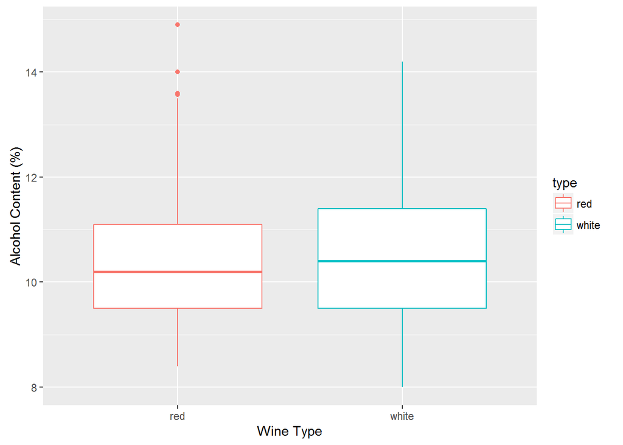

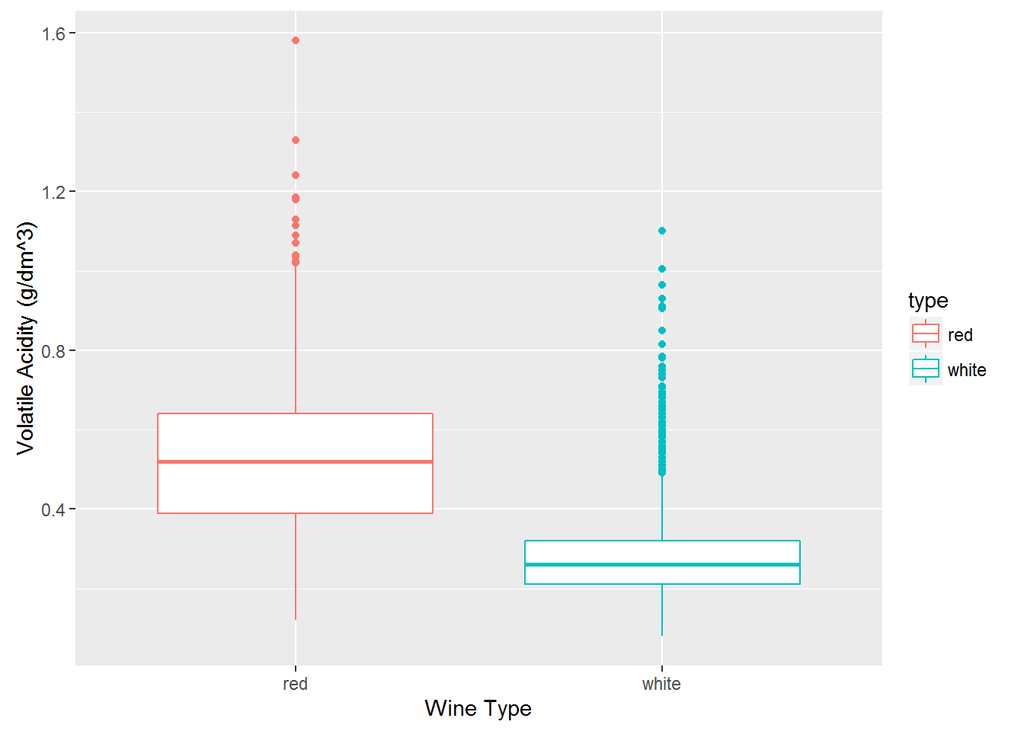

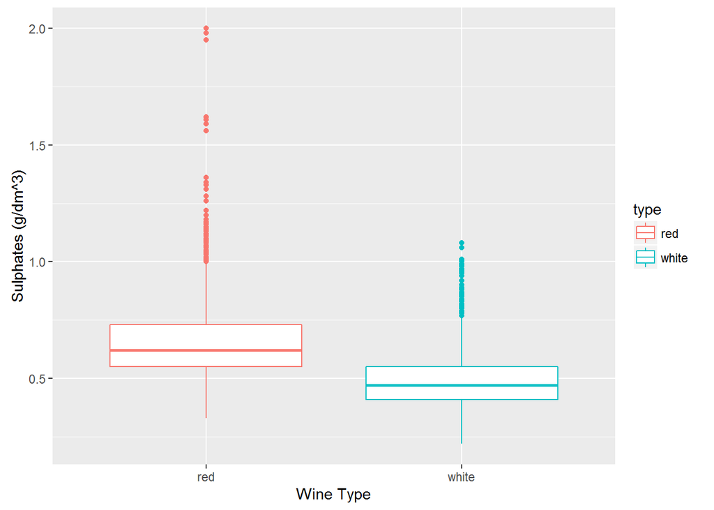

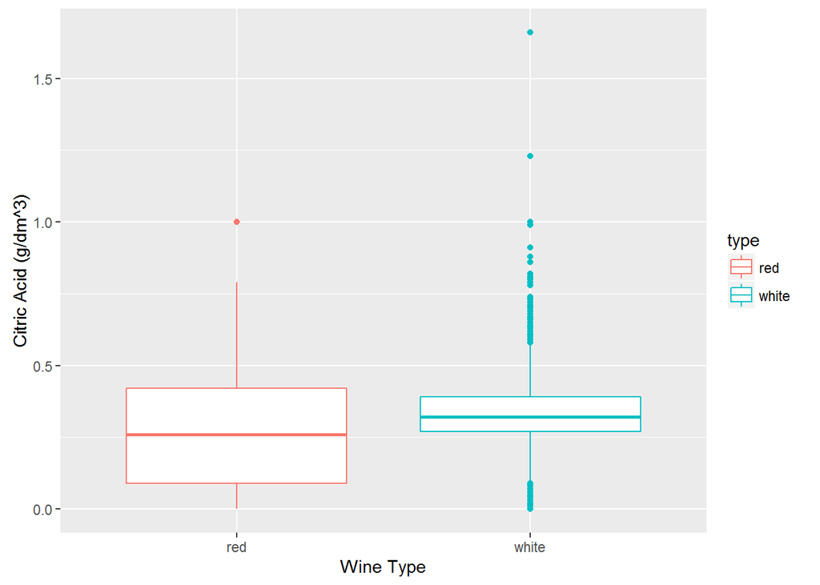

#### Do the white wines have similar correlations as the red wines?

The following plots show the top correlation variables for red wines (plotted in the correlations section above) with a linear fit and compared to the same variables for white wines. Because the variation is so high and the quality ratings are discrete, I’ve marked the mean value of each variable with an X for easier comparison of the mean values.

White wine quality also has the strongest correlation to alcohol content and a very similar slope. There is also a negative corrletion to volatile.acidity though it is not as strong as it is for the reds. Unlike the reds correlations as shown above, there is very little correlation to sulphates and citric.acid for white wines.

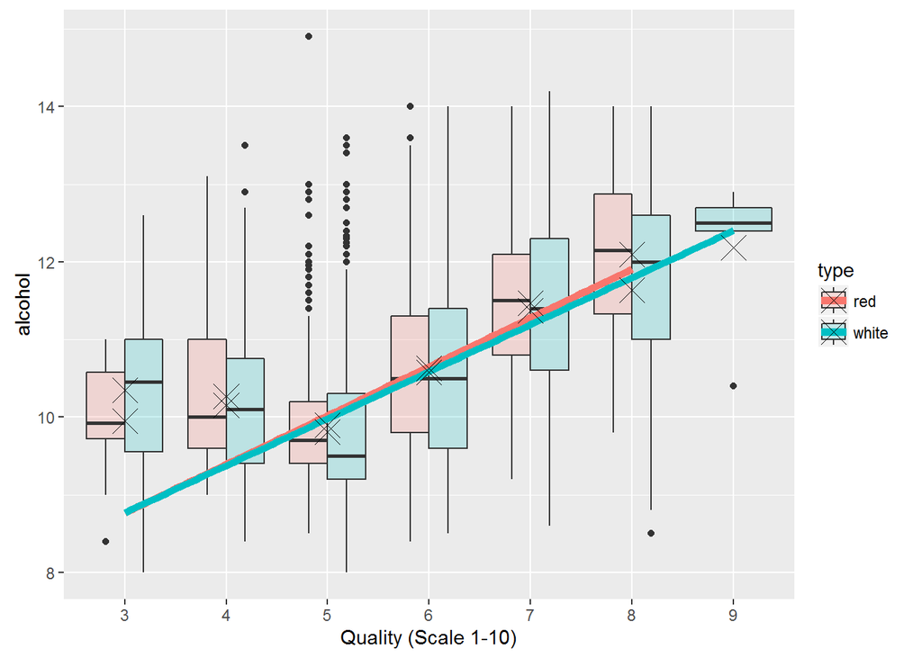

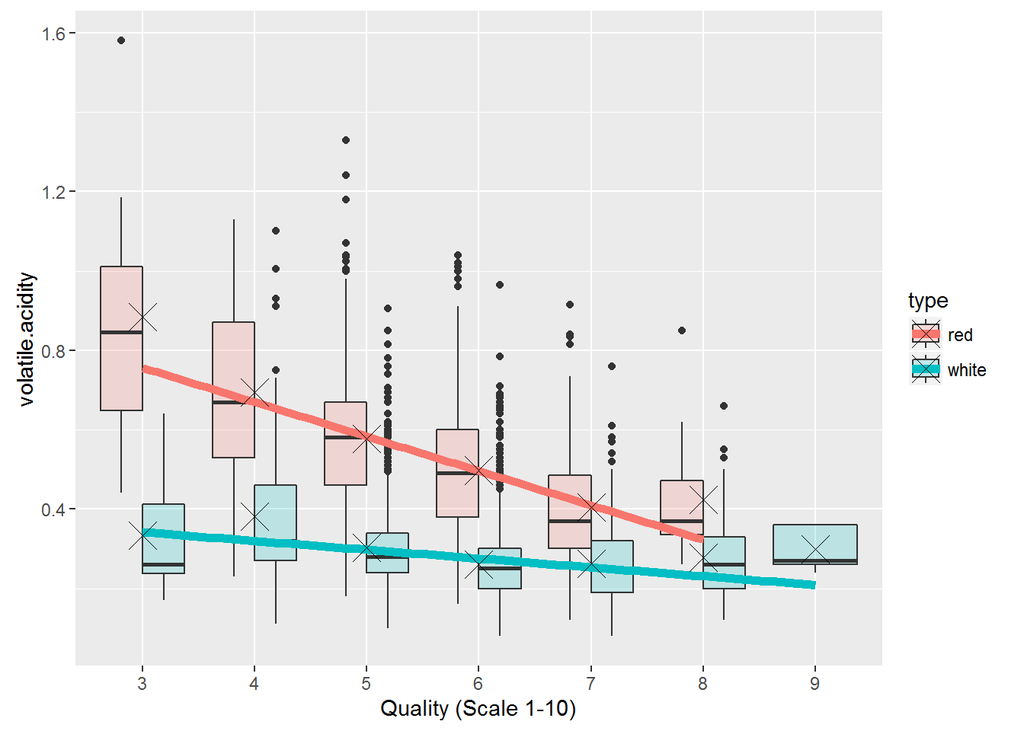

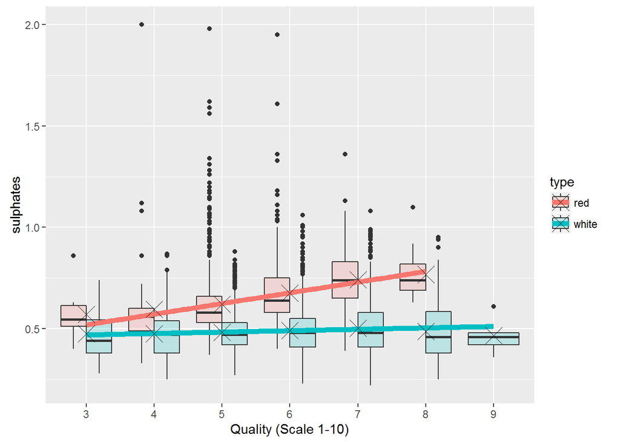

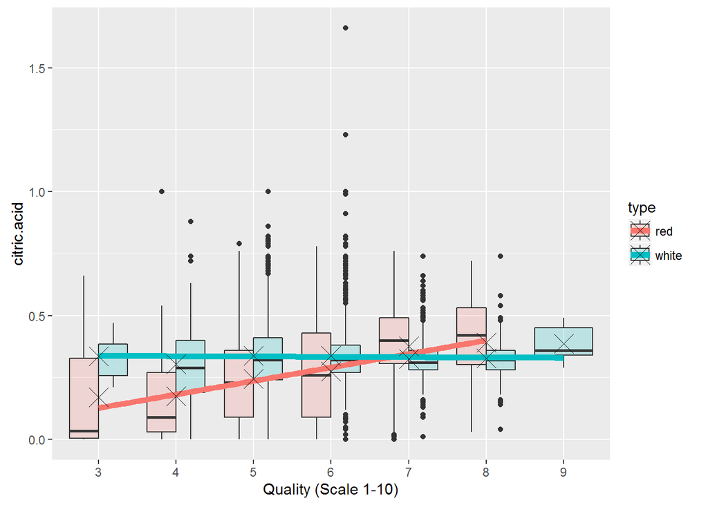

Based on these plots, alcohol and volatile acidity have similar trends for both types of wine, while sulphates and citric acid are distinctly different. Rather, the white wines show very little correlation to the sulphates and citric acid while the red wines do. For one of my final plots involving red and white wines, I will focus on alcohol and volatile acidity because they both show some trend. Otherwise, there do not seem to be many similarity between red and white wines with regard to quality trends.

## Final Plots

Notes - For comparisons between wines and to quality, it is more useful to factor the quality values. I create new columns called quality.f.

### Plot 1:

#### Comparison of variable distributions

The first plot combines my comparison of the distributions of the top 4 variables.

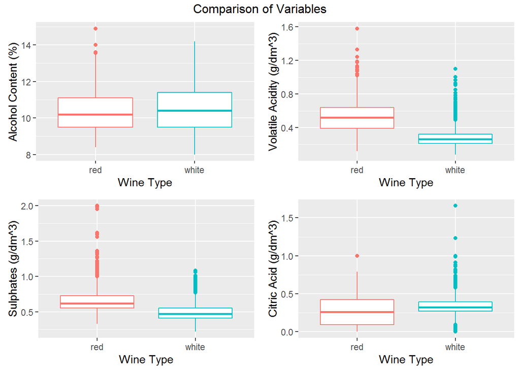

Discussion:

The boxplots show a clear difference for volatile acidity and sulphates, with white wines having lower values for both. The median and inner quartile for alcohol content and citric acid are very similar in terms of absolute values, though the t-test earlier do indicate that they are statistically different. For citric acid, the white wines are interesting. They have a very small spread for most data, but then there are many outliers. This indicates that the data itself has a rather large spread and is not particulary normally distributed. The most interesting conculsion from this plot is that the chemical properties for red and whites can be quite different even though I’d think since they are wine made from grapes that they’d be very similar.

### Plot 2:

#### Highest correlated variable for quality

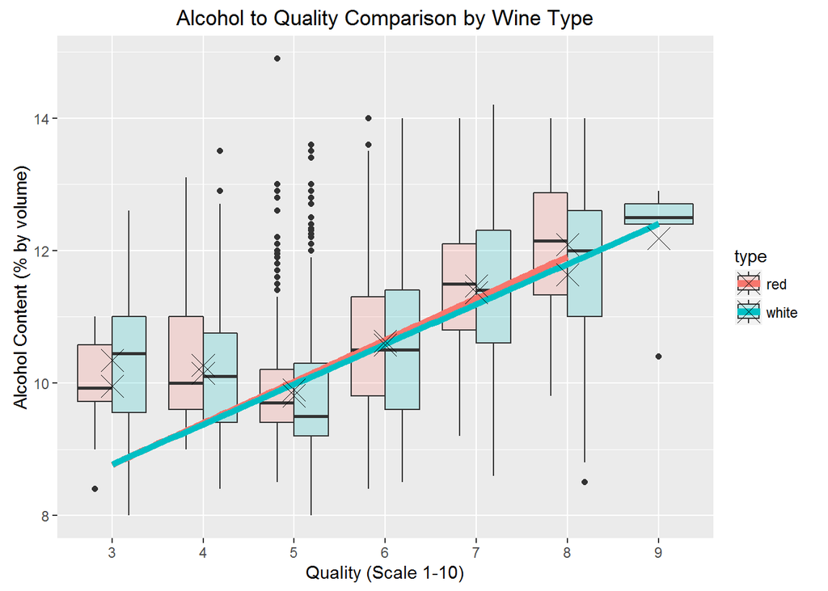

### Discussion:

Both red and white wines show strong a trend toward higher alcohol content for the higher rated wines (quality > 5). The trend is less clear for the poorer (quality < 5) wines for both red and whites. There are also several outliers for the average (quality = 5) wines which indicate there are many variable to influence the quality of wine other than the alcohol content. It is worth noting that there are fewer samples for the extremes (Quality = 3,4,8, or 9) than the more average wines.

Note: Mean values are denoted with an ‘X’

### Plot 3

#### Multivariate Plot for Red Wines

##### Combining Alcohol + Volatile Acidity to Quality

By combining both alcohol and volatile acidity (the two highest correlated variables for both reds and whites) in a scatter plot, I can assign the color to the quality. I’ve assigned a color palette to the quality ratings to the trends and added regression lines. I removed data that had quality ratings of 3, 8, and 9 because there are few data points and they tend to make color distinction more difficult. I also limited the x-axis to (0, 1.25) thus removing 2 outliers from the red dataset.

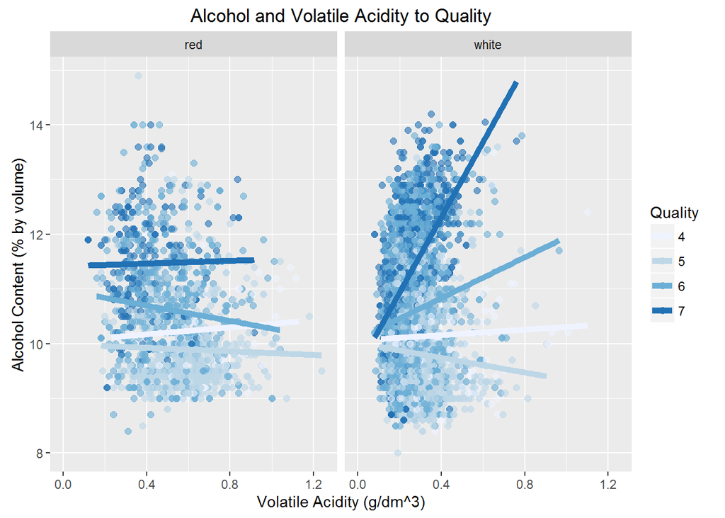

#### Discussion:

We can see that for the red wines, the correlations between alcohol to quality and volatile acidity to quality can be combined to show a multivariate relationship. There are more wines with quality 6 and 7 toward both the upper-left (high alcohol, low volatile acidity) portion of the plot while wines with qualites 5, 4,occupy more of the lower-right portion of the plot (low alcohol, high volatile acidity). However, the data is spread out a lot and there are no distinct boundaries in either axis. The regression lines help show separation with regard to alcohol content, but are still difficult to understand separation with regard to volatile acidity. Because most of the data falls in the quality 5 or 6 rating, these trend lines are most representative of the dataset. The red wines show a slightly negative slope for these two ratings. However, the white wines show both a positive (qualty = 6) and a negative slope (quality = 5) and thus a much less clear trend for alcohol to volatile acidity.

The white wines show some separation in the vertical direction (along the Alcohol axis), but the separation along the x-axis (Volatile acidity) is not as clear. As shown earlier, the white wines have significantly lower volatile acidity on average. There is likely a threshold in volate acidity that begins to turn a wine bad (perhaps around 0.7 or 0.8 g/dm^3), and the white wines simply do not cross this threshold as frequency as the reds.

While the scatterplots themselves do not show any clear trends, it is interesting to see a slight separation of wine qualities when colored by quality. Particularly for the red wines, the high quality wines tend to have higher alcohol content and lower volatile acidity. For white wines, the trends are not as visible, particularly for volatile acidity.

## Reflections

I explored both red wine and white wine datasets to find any interesting trends with quality and to compare trends between red and white wines. Most variables for the red wines are normally distributed though some were long-tailed. After finding correlations to quality within the red wine dataset, I limited most analysis to these variables (alcohol, volatile acidity, sulphates, and citric acid). The white wines have noticeably lower values of volatile acidity and sulphates, while alcohol and citric acid were more similar (though statistically different). I’d like to investigate further why white wines tend to have less volatile acidity and sulphates. Because I limited my analysis mostly to these 4 variables, there are likely other interesting discoveries among the other variables that could be further explored.

Both reds and whites follow a similar trend with regard to alcohol, that is a positive correlation. This finding was somewhat surprising to me because generally alcohol alone is considered to have a foul smell/taste and I would imagine the higher alcohol wines would have a stronger alcohol taste. Of course, the cause of this correlation can’t be determined from this dataset except to note that there is a correlation for both red and white wines. It would be worth to investigate why wines vary in alcohol content in the first place, whether a change in alcohol over a couple percent can be even tasted, and consider other rigorous tests to make any conclusions about this common trend.

I tried to create a linear model based on alcohol, volatile acidity, and sulphates that did identify the quality ratings of wines slightly better than assuming any given wine was of the median quality rating. Of course, this is particular to the Vinho Verde wine dataset, and it would be interesting to apply this model to other wine datasets. A more sophisticated model would involve testing on a different set than what the model was generated from.

Both datasets shows large spreads in their values for each quality rating and made it difficult to visualize underlying trends. However, the medians did help reveal these trends by using boxplots. The positive trend for alcohol content was clear, and both the reds and whites showed negative trends for volatile acidity. The description of this attribute states that high volatile acidity can lead to an unpleasant vinegar taste so it is possible that higher volatile acidity causes a lower quality rating, but much more rigorous tests are needed to prove this relationship. An experiment that changes only this variable while holding the rest constant could determine whether this variable causes poor quality ratings or if the correlation has different root causes.

Another difficulty with this dataset was the limited quality ratings. Over 75% of the data had a rating of either 5 or 6. It would useful to have a dataset that either uses a larger rating (perhaps 0 -100) scale, or find a dataset that includes more of the extreme quality ratings.